# STAT 361 - RECITATION 10

# Topic : Density Estimation

### İrem Tanrıverdi, iremt@metu.edu.tr

### Date: 09.06.2022

# Probability Density Estimation

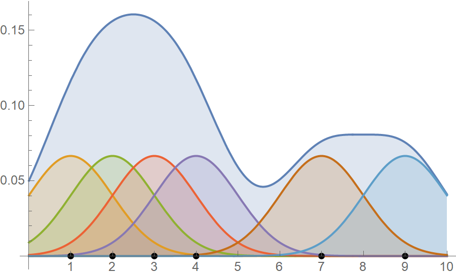

**Probability density is the relationship between observations and their probability. Some outcomes of a random variable will have low probability density and other outcomes will have a high probability density. The overall shape of the probability density is referred to as a probability distribution, and the calculation of probabilities for specific outcomes of a random variable is performed by a probability density function, or PDF for short. It is useful to know the probability density function for a sample of data in order to know whether a given observation is unlikely, or so unlikely as to be considered an outlier or anomaly and whether it should be removed. Knowing the probability distribution for a random variable can help to calculate moments of the distribution, like the mean and variance, but can also be useful for other more general considerations, like determining whether an observation is unlikely or very unlikely and might be an outlier or anomaly. It is also helpful in order to choose appropriate learning methods that require input data to have a specific probability distribution. It is unlikely that the probability density function for a random sample of data is known. As such, the probability density must be approximated using a process known as probability density estimation. There are a few steps in the process of density estimation for a random variable. The first step is to review the density of observations in the random sample with a simple histogram. From the histogram, we might be able to identify a common and well-understood probability distribution that can be used, such as a normal distribution. If not, we may have to fit a model to estimate the distribution.**

**Please keep in mind that;**

- Histogram plots provide a fast and reliable way to visualize the probability density of a data sample.
- Parametric probability density estimation involves selecting a common distribution and estimating the parameters for the density function from a data sample.
- Nonparametric probability density estimation involves using a technique to fit a model to the arbitrary distribution of the data, like kernel density estimation.Density estimation builds an estimate of some underlying probability density function using an observed data sample. Density estimation can either be parametric, where the data is from a known family, or nonparametric, which attempts to flexibly estimate an unknown distribution.

Density estimation is a collection of methods for constructing an estimate of a probability density, as a function of an observed sample of data. Namely, we observe $𝑋_1, ..., 𝑋_n$ and we want to recover the underlying probability density function generating our dataset.

A density estimation problem requires a nonparametric approach if we have no information about the target distribution other than the observed data. It is unlikely that the probability density function for a random sample of data is known. As such, the probability density must be approximated using a process known as probability density estimation.

It is useful to know the probability density function for a sample of data in order to know whether a given observation is unlikely, or so unlikely as to be considered an outlier or anomaly and whether it should be removed. It is also helpful in order to choose appropriate learning methods that require input data to have a specific probability distribution. Probability Density Estimation comes handy in many outlier detection algorithms where we seek to estimate “true” distribution based on sample observations and then classify some of existing or new observations as outlier or not.

## Univariate Density Estimation

### Histograms:

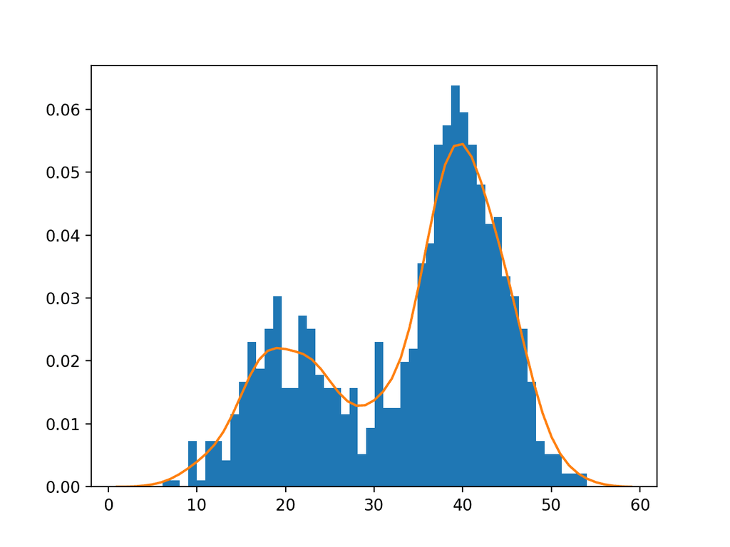

**The histogram (Silverman, 1986) is the oldest (dating to the 1840’s (Friendly, 2005)) and least sophisticated method of density estimation. The main advantages are its extreme simplicity and speed of computation. A histogram is piecewise constant (hence not at all smooth) and can be extremely sensitive to the choice of bin origin.**

Histogram plots provide a fast and reliable way to visualize the probability density of a data sample. A histogram is a plot that involves first grouping the observations into bins and counting the number of events that fall into each bin. The counts, or frequencies of observations, in each bin are then plotted as a bar graph with the bins on the x-axis and the frequency on the y-axis.

**The choice of the number of bins is important as it controls the coarseness of the distribution (number of bars) and, in turn, how well the density of the observations is plotted. It is a good idea to experiment with different bin sizes for a given data sample to get multiple perspectives or views on the same data. For example, observations between 1 and 100 could be split into 3 bins (1-33, 34-66, 67-100), which might be too coarse, or 10 bins (1-10, 11-20, … 91-100), which might better capture the density.**

We split the sample space up into bins, count how many samples fall into each bin, and then divide the counts by the total number of samples. If we hold the bins fixed and take more and more data, then by the law of large numbers we anticipate that the relative frequency for each bin will converge on the bin’s probability.

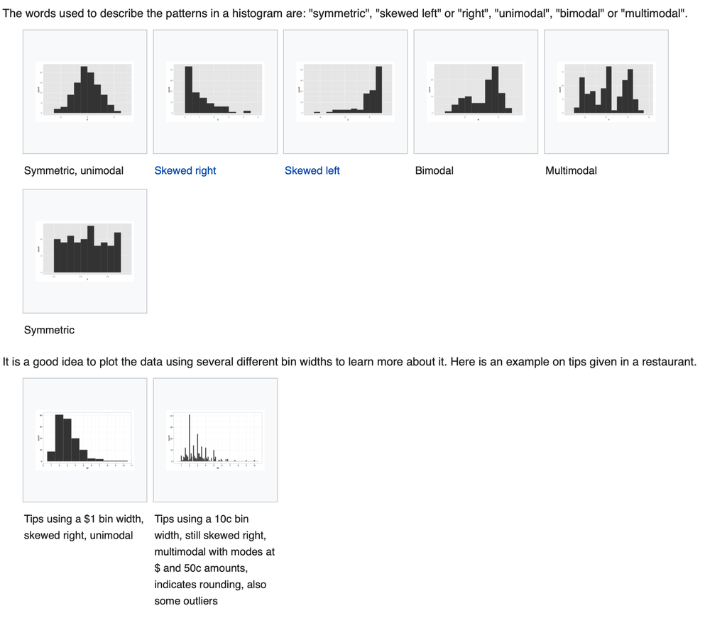

### 1. Sturges’ Rule:

Although Sturges’ rule tends to oversmooth the data and either Scott’s rule or FD are generally preferable, Sturges’ rule is the default in many statistical packages. Please run this code; ′?hist()′, you will see that break option is set to ‘Sturges’ as default.

According to Sturges, the optimal width of class intervals is given by

$$ \text{optimal width of class=}\frac{R}{log_2(n)}, \text{ where R is the sample range} $$

### The number of bins depends only on the sample size n, and not on the distribution.

**Note that** This choice of class interval is designed for data sampled from symmetric, unimodal populations, but is not a good choice for skewed distributions or distributions with more than one mode.

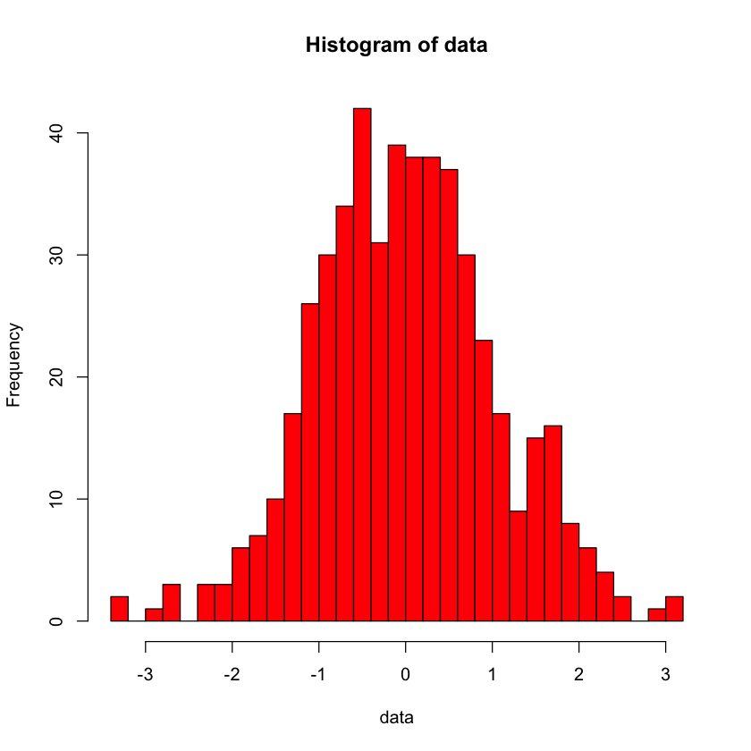

```r
# create sample data vector
data <- rnorm(500)

# create hsitogram with 30 bars
hist( data, breaks=30 , col="red")
```

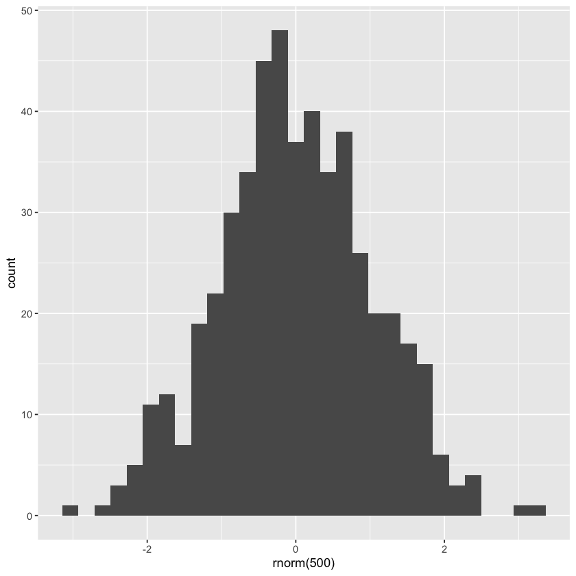

```r
x <- as.data.frame(rnorm(500))
library(ggplot2)

# create hsitogram with 30 bars
ggplot(x, aes( x= rnorm(500))) +
            geom_histogram( bins=30)
```

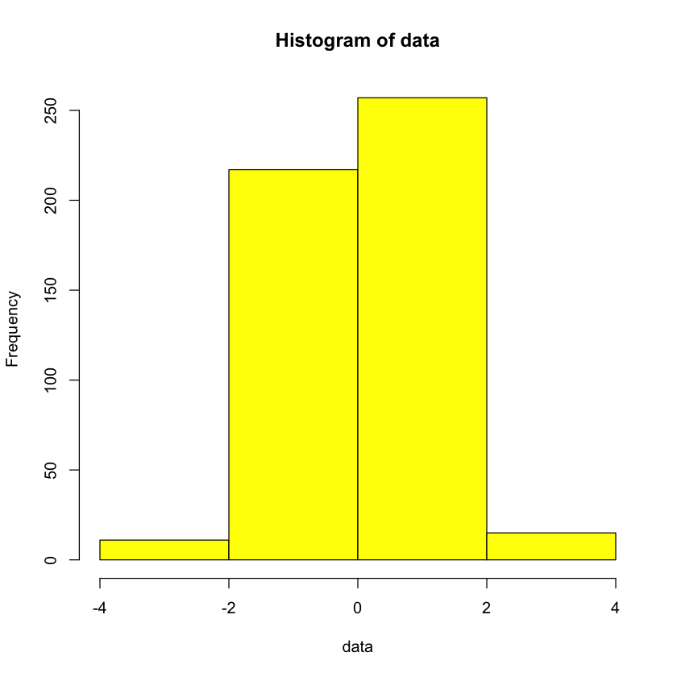

```r
# create sample data vector
data <- rnorm(500)

# create hsitogram with 30 bars
hist( data, breaks=3 , col="yellow")
```